# Lecture #14: Structured Programming

Nicholas J. Gotelli

23 March 2021

### Using snippets

```
snippet mbar
################

snippet mlab
# ${1:label} ------------------------
```

### Building a Function Template

```
snippet mfun
##############################
# FUNCTION: ${1:funname}
# purpose:
# input:
# output:
#--------------------
${1:funname} <- function() {


 message("testing...${1:funname}")
}
```

### Pseudocode

*pseudocode* is a simple list of instructions that gives the overall flow of the program without (yet) specifying the exact language and functions. At the most basic, it is just a list of what a program will do. Here, for example is generic pseudocode that describes about 95% of the programming chores we face:

```
Get data
Calculate stuff
Summarize output
Graph results
```

### Structured Programming With PseudoCode And Functions

Let’s use the pseudocode to build a program.

```
get_data()
calculate_stuff()
summarize_output()
graph_results()
```

Now we use our template to build 4 functions and then run them

```r
# Sample program to illustrate structured programming with functions
# 9 March 2017
# NJG

# All functions must be declared at the top before they are used
##################################################
# FUNCTION: get_data
# purpose:
# input:
# output:
#-------------------------------------------------
get_data <- function() {


 message("testing...get_data")
}
##################################################
# FUNCTION: calculate_stuff
# purpose:
# input:
# output:
#-------------------------------------------------
calculate_stuff <- function() {


 message("testing...calculate_stuff")
}
##################################################
# FUNCTION: summarize_output
# purpose:
# input:
# output:
#-------------------------------------------------
summarize_output <- function() {


 message("testing...summarize_output")
}
##################################################
# FUNCTION: graph_results
# purpose:
# input:
# output:
#-------------------------------------------------
graph_results <- function() {


 message("testing...graph_results")
}
##################################################
library(ggplot2)
get_data()
calculate_stuff()
summarize_output()
graph_results()
```

### Sourcing Functions In A Separate Script File

1. Cut and copy all functions to new Rscript `MyFunctions.R`
2. Create new file called `MyShortProgram.R`
3. Add following code to the new program:

```
source("MyFunctions.R")
get_data()
calculate_stuff()
summarize_output()
graph_results()
```

the `source` function runs a specified R script file automatically. It is equivalent to running `<Control><Shift><Enter>` from within a script file.

#### Advantages of Sourcing

1. Let’s you build a library of reusable functions
2. Corrections can be made once and then applied to all programs that use them

#### Disadvantages of Sourcing

1. Breaks code into two separate files, both of which must be present.
2. Discourages minor tweaks to functions because they will affect other programs.

#### Compromise solution

1. Maintain a single R script that contains the functions you have built.
2. Cut and paste functions that you want from your function file to your script file.
3. When you create new functions that are useful, append a copy to your function file.
4. A new idea: try creating a separate little R script for each function and then source those with single lines of code! (adapted from R scripts of Giovanni Strona)

#### Building the `CalculateStuff()` Function

```r
##################################################
# FUNCTION: calculate_stuff;
# purpose: Fits an ordinary least squares regression model
# input: x and y vectors of numeric. Must be same length
# output: entire model summary from lm
#-------------------------------------------------
calculate_stuff <- function(x_var=runif(10),y_var=runif(10)) {
reg_model <- lm(y_var~x_var)
return(summary(reg_model))
}
calculate_stuff()
```

#### Building the `SummarizeOutput()` Function

```r
##################################################
# FUNCTION: summarize_output
# purpose: pull elements from model summary list
# input: list from summary call of lm
# output: vector of regression residuals
#-------------------------------------------------
summarize_output <- function(z=NULL) {
if(is.null(z)) {
  z <- summary(lm(runif(10)~runif(10)))
}
  return(z$residuals)
}
summarize_output()
```

#### Building the `GraphResults()` Function

```
## Message: Regression graph created
```

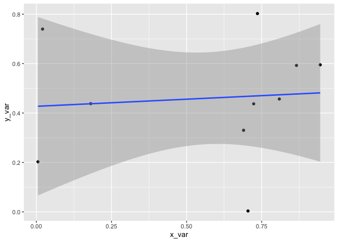

```r
##################################################
# FUNCTION: graph_results
# purpose: graph data and fitted OLS line
# input: x and y vectors of numeric. Must be same length
# output: creates graph
#-------------------------------------------------
graph_results <- function(x_var=runif(10), y_var=runif(10)) {
d_frame <- data.frame(x_var,y_var)

reg_plot <- ggplot(data=d_frame) +
            aes(x=x_var,y=y_var) +
            geom_point() +
            stat_smooth(method=lm,se=0.95) # default se=0.95
print(reg_plot)
 ggsave(filename="reg_plot.pdf",plot=reg_plot,device="pdf")

message("Message: Regression graph created")
}
graph_results()
```

```
## Message: Regression graph created
```

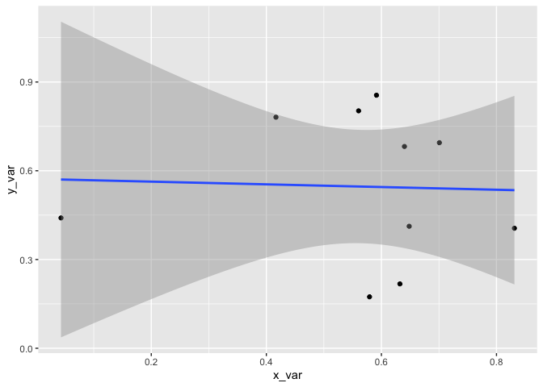

```r
str(graph_results())
```

#### Building the `get_data()` Function

```r
##################################################
# FUNCTION: get_data
# purpose: read in a .csv file
# input: .csv file
# output: data frame
#-------------------------------------------------
get_data <- function(file_name=NULL) {
if(is.null(fileName)) {
  d_frame <- data.frame(ID=101:110,
                          var_a=runif(10),
                          var_b=runif(10))
}  else {
  d_frame <- read.table(file=file_name,
                          header=TRUE,
                          sep=",")
  }
  return(data_frame)
}


get_data()
```

#### Linking each of the functions

Now each function works, but they are all using their defaults and are not “talking” to each other. To link them, we first must create a very small number of **global variables** which can be passed down to some of our functions as parameters. In this case, we need 3 of them:

1. The name of the inputdata file
2. The column of data in the data frame that contains the x variable
3. The column of data in the data frame that contains the y variable

```r
# Global variables
#----------------------------------------------
ant_file <- "antcountydata.csv" # New England ant county data
x_col <- 7 # column 7, latitude center of each county
y_col <- 5 # column 5, number of ant species
#----------------------------------------------

# Program body
temp1 <- get_data(file_name=ant_file) # construct the data frame

pred <- temp1[,x_col] # extract the predictor variable
res <- temp1[,y_col] # extract the response variable

temp2 <- calculate_stuff(x_var=pred,y_var=res) # fit the model
temp3 <- summarize_output(temp2) # extract the residuals

graph_results(x_var=pred, y_var=res) # create graph

print(temp3) # show the residuals
print(temp2) # show the model summary
```

#### Overall Program Structure

```
# Header #############################
# author, date, what program does -- add lots of detail

# Initialization ####################
# call libraries (e.g. tidyverse)
# set random number seed (use set.seed(integer))

# Functions ########################
# include all functions here
# OR.. source(Functions.R) OR source(function1.R)
                              source(function2.R)
                              source(function3.R)

# Global Variables #####################
# should be relatively few of these
# use them to pass to functions

# Program Body #########################
# use functions and global variables
# use temp variables to hold intermediate pieces of output
# functions should create and save all graphical and numeric output
```

#### Snippet for a general script template

```
snippet m_script
    # Description --------------------------------
    # Description of script

    # 16 Mar 2022
    # NJG

    # Initialize ---------------------------------
    library(tidyverse)

    # set.seed(100)

    # library(TeachingDemos)
    # char2seed("espresso withdrawal")
    # char2seed("espresso withdrawal",set=FALSE)

    # Load Functions -----------------------------

    # Global Variables ---------------------------

    # Program Body -------------------------------
```